# Penguins analysis part 2

Correlation - PDA

Lesley Duff

2023-10-23

# Correlation

```r
library(GGally)
library(ggplot2)
library(tidyverse)
```

```r
# read in cleaned data
penguins <- read_csv("../clean_data/penguins.csv")
```

## Correlation matrix

Create a correlation matrix using GGally::ggcorr() that shows the correlation between bill length, bill depth, flipper length, and body mass across species. (Hint: you can add correlation coefficient labels to your plot if you look at the ?ggcorr help file)

Write a short summary of your results.

### Correlation between bill length, bill depth, flipper length, and body mass across species

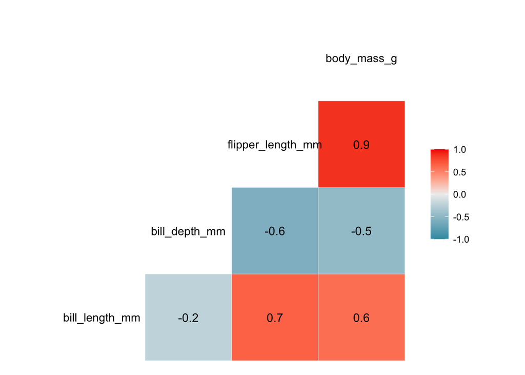

```r
# 4.5 Concept of correlation and correlation matrices
corr_data_penguins <- penguins %>%
  select(bill_length_mm, bill_depth_mm, flipper_length_mm, body_mass_g)
#correlation between bill length, bill depth, flipper length, and body mass across species.
#View(penguins)
# ?ggcorr

# Pearson correlation coefficients, using pairwise observations
# (default method)
# Pearson’s correlation:
# corresponds to the covariance of the two variables normalized (i.e., divided) by the product of their standard deviations.

# By default, the midpoint of the gradient is set at 0
#, which indicates a null correlation

ggcorr(corr_data_penguins, label = TRUE)
```

- Strong positive correlation between flipper length and body mass.  
  Close to nearly perfect linear relationship. The longer the flippers the heavier the penguin
- strong positive correlation between bill length and flipper length and body mass. Longer bills mean longer flippers and heavier penguins
- Bill depth strong negative correlation with flipper length and body mass, So as bill depth increases, flipper length and body mass tend to decrease
- Bill length and and bill depth relatively weak negative correlation. As bill length increases, bill depth tends to decrease and vice versa, but the relationship is not very strong.